# R Notebook

# Series Temporales

Primero un ejemplo de internet que está mejor explicado: https://rpubs.com/joser/SeriesTemporalesBasicas

Definición de una serie temporal En esta primera parte vamos a trabajar con el fichero gas6677.dat que contiene datos mensuales del consumo de gasolina en España entre enero de 1966 y agosto de 1977. Una vez situado el fichero en el directorio de trabajo lo leemos y creamos un vector llamado gas con el comando

```r
gas = scan('http://verso.mat.uam.es/~joser.berrendero/datos/gas6677.dat')
```

```
Read 140 items
```

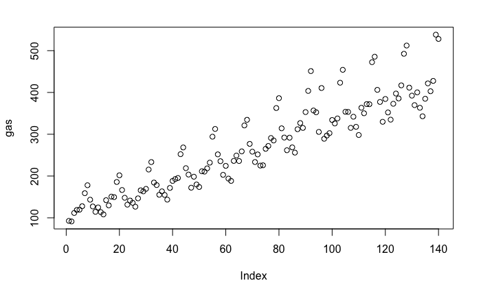

```r
plot(gas)
```

```r
gas
```

```
  [1]  92.718  91.380 111.643 118.888 119.432 127.796 158.943 178.013 143.385 127.179 114.403 124.900 113.661
 [14] 108.224 142.256 129.835 150.735 149.554 185.792 201.758 166.565 148.048 131.581 141.315 135.951 126.615
 [27] 146.647 165.822 163.365 169.294 215.538 233.427 184.402 178.432 155.179 163.355 154.844 143.552 171.573
 [40] 188.322 192.756 195.296 252.288 268.379 218.810 203.545 172.148 198.381 179.759 173.821 211.387 210.551
 [53] 218.371 232.057 294.173 312.700 251.891 235.560 202.876 224.383 193.916 188.375 236.187 249.037 235.957
 [66] 258.980 321.085 334.562 276.932 258.269 233.532 251.755 225.010 225.742 265.159 271.986 290.953 285.108
 [79] 362.687 386.347 314.205 292.124 261.740 291.810 268.578 256.063 312.041 326.741 315.157 353.016 403.662
 [92] 451.098 356.811 352.566 305.580 410.614 289.186 296.881 302.589 334.091 325.790 337.782 423.297 454.172
[105] 353.727 353.413 315.272 341.902 317.760 298.188 363.429 350.203 372.149 371.877 472.458 485.517 406.223
[118] 377.262 329.794 384.350 352.200 334.938 372.891 397.388 385.657 416.961 492.480 512.209 411.514 392.380
[131] 369.671 400.243 363.367 342.979 384.936 421.718 402.877 427.615 538.254 528.007
```

Vemos que el gráfico resultante no es el más apropiado para describir una serie temporal. Si queremos que R trate a un objeto como serie temporal, tenemos que determinar apropiadamente sus características con el comando ts. Para definir la serie correctamente escribimos:

```r
gas.ts = ts(gas, start = c(1966,1), frequency = 12)
gas.ts
```

```
         Jan     Feb     Mar     Apr     May     Jun     Jul     Aug     Sep     Oct     Nov     Dec
1966  92.718  91.380 111.643 118.888 119.432 127.796 158.943 178.013 143.385 127.179 114.403 124.900
1967 113.661 108.224 142.256 129.835 150.735 149.554 185.792 201.758 166.565 148.048 131.581 141.315
1968 135.951 126.615 146.647 165.822 163.365 169.294 215.538 233.427 184.402 178.432 155.179 163.355
1969 154.844 143.552 171.573 188.322 192.756 195.296 252.288 268.379 218.810 203.545 172.148 198.381
1970 179.759 173.821 211.387 210.551 218.371 232.057 294.173 312.700 251.891 235.560 202.876 224.383
1971 193.916 188.375 236.187 249.037 235.957 258.980 321.085 334.562 276.932 258.269 233.532 251.755
1972 225.010 225.742 265.159 271.986 290.953 285.108 362.687 386.347 314.205 292.124 261.740 291.810
1973 268.578 256.063 312.041 326.741 315.157 353.016 403.662 451.098 356.811 352.566 305.580 410.614
1974 289.186 296.881 302.589 334.091 325.790 337.782 423.297 454.172 353.727 353.413 315.272 341.902
1975 317.760 298.188 363.429 350.203 372.149 371.877 472.458 485.517 406.223 377.262 329.794 384.350
1976 352.200 334.938 372.891 397.388 385.657 416.961 492.480 512.209 411.514 392.380 369.671 400.243
1977 363.367 342.979 384.936 421.718 402.877 427.615 538.254 528.007
```

El argumento frequency se utiliza para indicar la periodicidad de la serie (en este caso mensual), mientras que el argumento start indica la fecha de la primera observación (enero de 1966).

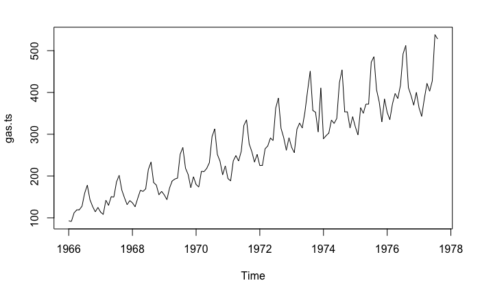

```r
plot(gas.ts)
```

Vemos ahora cómo el resultado depende de las características que hemos definido para la serie. Si queremos comparar la distribución del consumo de gasolina para cada mes, un gráfico útil es

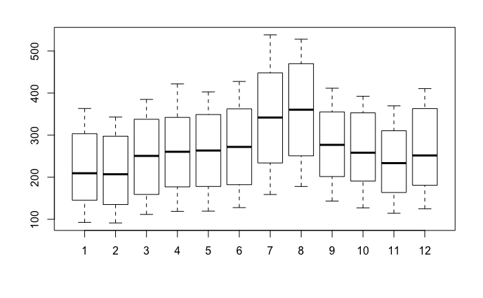

```r
boxplot(gas.ts ~ cycle(gas.ts)) #cycle gives the positions in the cycle of each observation.
```

El comando cycle determina la unidad de tiempo a la que pertenece cada observación de la serie:

```r
cycle(gas.ts)
```

```
     Jan Feb Mar Apr May Jun Jul Aug Sep Oct Nov Dec
1966   1   2   3   4   5   6   7   8   9  10  11  12
1967   1   2   3   4   5   6   7   8   9  10  11  12
1968   1   2   3   4   5   6   7   8   9  10  11  12
1969   1   2   3   4   5   6   7   8   9  10  11  12
1970   1   2   3   4   5   6   7   8   9  10  11  12
1971   1   2   3   4   5   6   7   8   9  10  11  12
1972   1   2   3   4   5   6   7   8   9  10  11  12
1973   1   2   3   4   5   6   7   8   9  10  11  12
1974   1   2   3   4   5   6   7   8   9  10  11  12
1975   1   2   3   4   5   6   7   8   9  10  11  12
1976   1   2   3   4   5   6   7   8   9  10  11  12
1977   1   2   3   4   5   6   7   8
```

Ejercicio: El fichero jj.dat contiene los beneficios trimestrales de la empresa Johnson & Johnson entre 1960 y 1980:

```r
jj = scan('http://verso.mat.uam.es/~joser.berrendero/datos/jj.dat')
```

```
Read 84 items
```

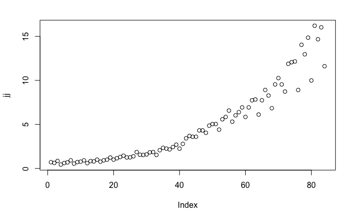

```r
plot(jj)
```

```r
jj
```

```
 [1]  0.710000  0.630000  0.850000  0.440000  0.610000  0.690000  0.920000  0.550000  0.720000  0.770000
[11]  0.920000  0.600000  0.830000  0.800000  1.000000  0.770000  0.920000  1.000000  1.240000  1.000000
[21]  1.160000  1.300000  1.450000  1.250000  1.260000  1.380000  1.860000  1.560000  1.530000  1.590000
[31]  1.830000  1.860000  1.530000  2.070000  2.340000  2.250000  2.160000  2.430000  2.700000  2.250000
[41]  2.790000  3.420000  3.690000  3.600000  3.600000  4.320000  4.320000  4.050000  4.860000  5.040000
[51]  5.040000  4.410000  5.580000  5.850000  6.570000  5.310000  6.030000  6.390000  6.930000  5.850000
[61]  6.930000  7.740000  7.830000  6.120000  7.740000  8.910000  8.280000  6.840000  9.540000 10.260000
[71]  9.540000  8.729999 11.880000 12.060000 12.150000  8.910000 14.040000 12.960000 14.850000  9.990000
[81] 16.200000 14.670000 16.020000 11.610000
```

Define la serie temporal y represéntala. ¿Cuál es el valor de la serie para el tercer trimestre de 1980? ¿Cuáles son las principales características (tendencia, estacionalidad) de esta serie?

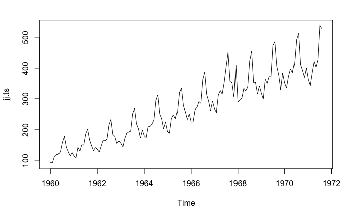

```r
jj.ts = ts(gas, start = c(1960,1), frequency = 12)
plot(jj.ts)
```

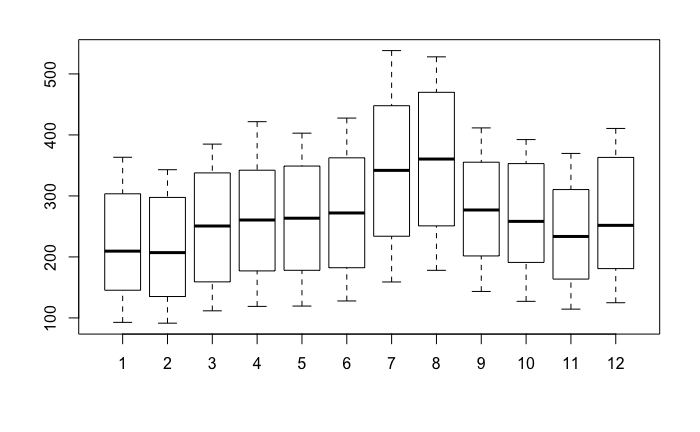

```r
boxplot(jj.ts ~ cycle(jj.ts))
```

## Descomposición de una serie

Es frecuente analizar las series temporales desde el punto de vista de sus componentes estructurales:

Serie observada = Tendencia + Efecto estacional + Residuos.

En este modelo, la serie observada es el resultado de sumar una tendencia que representa el comportamiento a largo plazo de la serie, un efecto estacional que describe sus fluctuaciones periódicas y un componente residual que describe las variaciones a corto plazo, normalmente impredecibles.

Con R es muy sencillo obtener una descomposición estructural de este tipo. Se usa el comando decompose:

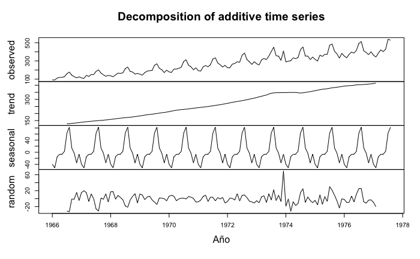

```r
gas.ts.desc = decompose(gas.ts)
plot(gas.ts.desc, xlab='Año')
```

Esta descomposición se basa en métodos elementales: la tendencia se calcula con una media móvil, el efecto estacional se calcula promediando los valores de cada unidad de tiempo para todos los periodos (por ejemplo, todos los meses de enero si la serie es mensual) y luego centrando el resultado. Finalmente, los residuos se obtienen restando a la serie observada las dos componentes anteriores. La descomposicion solo es totalmente adecuada si se dispone de un número completo de periodos (por ejemplo, un múltiplo de 12 si la serie es mensual).

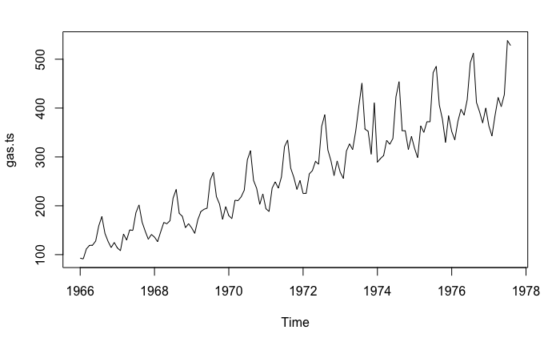

```r
plot(gas.ts)
```

## Transformaciones básicas de una serie

En el gráfico de gas.ts se observa que la serie no es estacionaria. La serie presenta una tendencia aparentemente lineal y una estacionalidad muy marcada (el consumo aumenta los meses de verano). Además, la amplitud de las fluctuaciones aumenta con el tiempo por lo que la variabilidad tampoco es constante. Sin embargo, muchos modelos importantes de series temporales corresponden a series estacionarias (es decir, sin tendencia ni estacionalidad y con variabilidad constante). Antes de ajustar un modelo estacionario tenemos que transformar la serie original.

Estabilización de la varianza: Para estabilizar la variabilidad se suelen tomar logaritmos. Esta transformación funcionará bien cuando la variabilidad sea aproximadamente proporcional al nivel de la serie. Representamos la serie transformada mediante

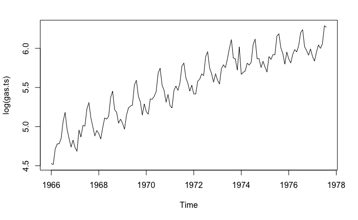

```r
plot(log(gas.ts))
```

Eliminación de tendencia: Una forma sencilla de eliminar una tendencia aproximadamente lineal es diferenciar la serie, es decir, considerar la serie de diferencias entre una observación y la anterior en lugar de la serie original. Si xt es una serie contenida en x, para calcular ∇xt=xt−xt−1 con R se escribe:

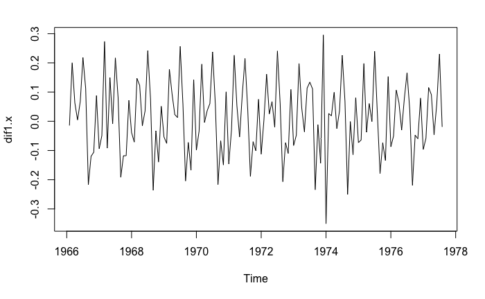

```r
x = log(gas.ts)
dif1.x = diff(x)
plot(dif1.x)
```

Eliminación de estacionalidad: Para eliminar la estacionalidad de una serie mensual se pueden tomar diferencias estacionales de orden 12. Si xt es la serie que queremos desestacionalizar, se trata de calcular ∇12xt=xt−xt−12:

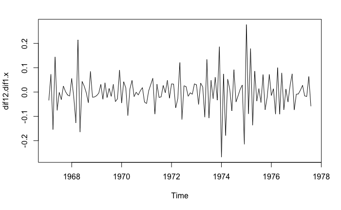

```r
dif12.dif1.x = diff(dif1.x, lag=12)
plot(dif12.dif1.x)
```

Ejercicio: Aplica las transformaciones adecuadas a la serie de beneficios de la empresa Johnson & Johnson para obtener una serie aproximadamente estacionaria.

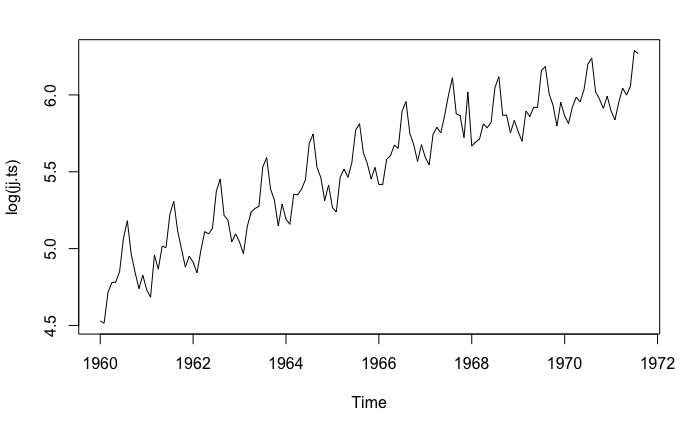

```r
plot(log(jj.ts))
```

Parece que no es necesario estabilizar la varianza.

Eliminar la tendencia

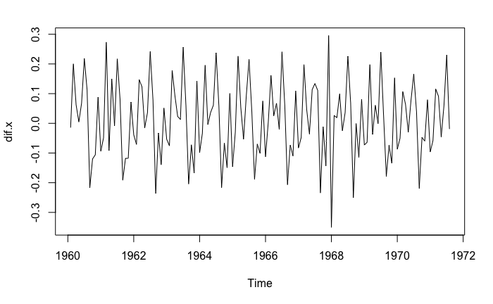

```r
x = log(jj.ts)
dif.x = diff(x)
plot(dif.x)
```

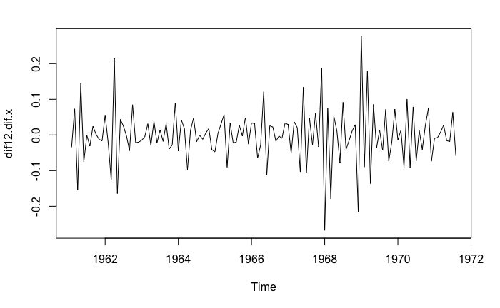

```r
dif12.dif.x = diff(dif.x, lag=12)
plot(dif12.dif.x)
```

# EJEMPLO MASTER

La estacionalidad de las series se puede interpretar de manera aditiva ó multiplicativa, esto es:

Modelo aditivo: Y(t)=T(t)+S(t)+ϵ(t)

Modelo multiplicativo: Y(t)=T(t)⋅S(t)⋅ϵ(t)

En ambos modelos:

Y(t) es la secuencia que representa a la serie numérica. S(t) es la componente estacional que representa las variaciones que se presentan con la frecuencia T(t) es la componente de tendencia que representa la variación evolutiva de la serie respecto al tiempo ϵ(t) es la componente de error ó ruido blanco de la serie Veremos un ejemplo de una serie temporal mensual con frecuencia anual, cada 12 meses.

Cargamos los datos y los representamos

```r
data("AirPassengers")
AP <- AirPassengers
frequency(AP)
```

```
[1] 12
```

```r
AP
```

```
     Jan Feb Mar Apr May Jun Jul Aug Sep Oct Nov Dec
1949 112 118 132 129 121 135 148 148 136 119 104 118
1950 115 126 141 135 125 149 170 170 158 133 114 140
1951 145 150 178 163 172 178 199 199 184 162 146 166
1952 171 180 193 181 183 218 230 242 209 191 172 194
1953 196 196 236 235 229 243 264 272 237 211 180 201
1954 204 188 235 227 234 264 302 293 259 229 203 229
1955 242 233 267 269 270 315 364 347 312 274 237 278
1956 284 277 317 313 318 374 413 405 355 306 271 306
1957 315 301 356 348 355 422 465 467 404 347 305 336
1958 340 318 362 348 363 435 491 505 404 359 310 337
1959 360 342 406 396 420 472 548 559 463 407 362 405
1960 417 391 419 461 472 535 622 606 508 461 390 432
```

```r
typeof(AP)
```

```
[1] "double"
```

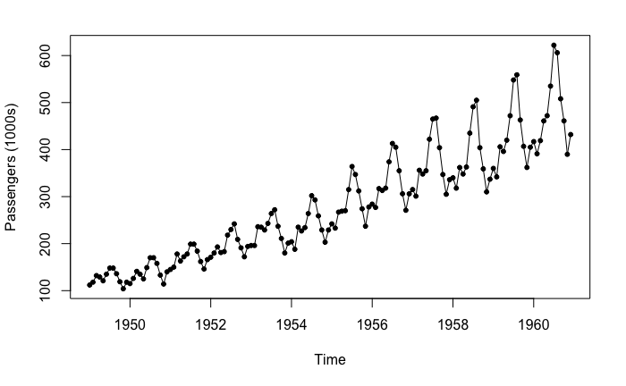

```r
plot(AP, ylab="Passengers (1000s)", type="o", pch =20)
```

Tiene una tendencia positiva y vemos un efecto estacional.

Tomamos los datos hasta 1959 incluído como entrenamiento y los datos en 1960 como test.

```r
AP_train <- window(AP, end=c(1959,12))
AP_test <- window(AP, start=1960)
```

Interpretamos los datos Cuando la estacionalidad parece tener más variación conforme la tendencia manifiesta su evolución, se usan modelos multiplicativos. Si no es más adecuado usar modelos aditivos. En este caso usaremos un modelo multiplicativo Ver: https://support.minitab.com/es-mx/minitab/18/help-and-how-to/modeling-statistics/time-series/supporting-topics/time-series-models/additive-and-multiplicative-models/

Descomponemos la serie: VEr: http://halweb.uc3m.es/esp/Personal/personas/jmmarin/esp/EDescrip/tema7.pdf

Con la función decompose se separa la serie de manera aditiva ó multiplicativa y se pueden observar los efectos:

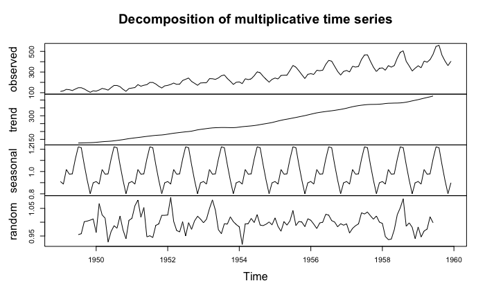

```r
AP.decompM <- decompose(AP_train, type = "multiplicative")
plot(AP.decompM)
```

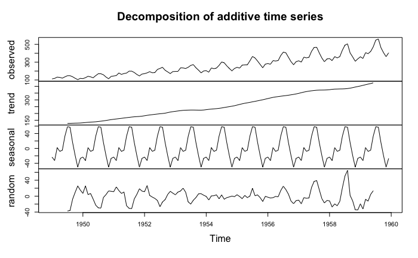

```r
AP.decompA <- decompose(AP_train, type = "additive")
plot(AP.decompA)
```

Vemos las series con las componentes:

```r
AP.decompM$seasonal
```

```
           Jan       Feb       Mar       Apr       May       Jun       Jul       Aug       Sep       Oct
1949 0.9100037 0.8873765 1.0182037 0.9754120 0.9798128 1.1115898 1.2221466 1.2135961 1.0609168 0.9217670
1950 0.9100037 0.8873765 1.0182037 0.9754120 0.9798128 1.1115898 1.2221466 1.2135961 1.0609168 0.9217670
1951 0.9100037 0.8873765 1.0182037 0.9754120 0.9798128 1.1115898 1.2221466 1.2135961 1.0609168 0.9217670
1952 0.9100037 0.8873765 1.0182037 0.9754120 0.9798128 1.1115898 1.2221466 1.2135961 1.0609168 0.9217670
1953 0.9100037 0.8873765 1.0182037 0.9754120 0.9798128 1.1115898 1.2221466 1.2135961 1.0609168 0.9217670
1954 0.9100037 0.8873765 1.0182037 0.9754120 0.9798128 1.1115898 1.2221466 1.2135961 1.0609168 0.9217670
1955 0.9100037 0.8873765 1.0182037 0.9754120 0.9798128 1.1115898 1.2221466 1.2135961 1.0609168 0.9217670
1956 0.9100037 0.8873765 1.0182037 0.9754120 0.9798128 1.1115898 1.2221466 1.2135961 1.0609168 0.9217670
1957 0.9100037 0.8873765 1.0182037 0.9754120 0.9798128 1.1115898 1.2221466 1.2135961 1.0609168 0.9217670
1958 0.9100037 0.8873765 1.0182037 0.9754120 0.9798128 1.1115898 1.2221466 1.2135961 1.0609168 0.9217670
1959 0.9100037 0.8873765 1.0182037 0.9754120 0.9798128 1.1115898 1.2221466 1.2135961 1.0609168 0.9217670
           Nov       Dec
1949 0.8002132 0.8989616
1950 0.8002132 0.8989616
1951 0.8002132 0.8989616
1952 0.8002132 0.8989616
1953 0.8002132 0.8989616
1954 0.8002132 0.8989616
1955 0.8002132 0.8989616
1956 0.8002132 0.8989616
1957 0.8002132 0.8989616
1958 0.8002132 0.8989616
1959 0.8002132 0.8989616
```

```r
AP.decompM$trend
```

```
          Jan      Feb      Mar      Apr      May      Jun      Jul      Aug      Sep      Oct      Nov      Dec
1949       NA       NA       NA       NA       NA       NA 126.7917 127.2500 127.9583 128.5833 129.0000 129.7500
1950 131.2500 133.0833 134.9167 136.4167 137.4167 138.7500 140.9167 143.1667 145.7083 148.4167 151.5417 154.7083
1951 157.1250 159.5417 161.8333 164.1250 166.6667 169.0833 171.2500 173.5833 175.4583 176.8333 178.0417 180.1667
1952 183.1250 186.2083 189.0417 191.2917 193.5833 195.8333 198.0417 199.7500 202.2083 206.2500 210.4167 213.3750
1953 215.8333 218.5000 220.9167 222.9167 224.0833 224.7083 225.3333 225.3333 224.9583 224.5833 224.4583 225.5417
1954 228.0000 230.4583 232.2500 233.9167 235.6250 237.7500 240.5000 243.9583 247.1667 250.2500 253.5000 257.1250
1955 261.8333 266.6667 271.1250 275.2083 278.5000 281.9583 285.7500 289.3333 293.2500 297.1667 301.0000 305.4583
1956 309.9583 314.4167 318.6250 321.7500 324.5000 327.0833 329.5417 331.8333 334.4583 337.5417 340.5417 344.0833
1957 348.2500 353.0000 357.6250 361.3750 364.5000 367.1667 369.4583 371.2083 372.1667 372.4167 372.7500 373.6250
1958 375.2500 377.9167 379.5000 380.0000 380.7083 380.9583 381.8333 383.6667 386.5000 390.3333 394.7083 398.6250
1959 402.5417 407.1667 411.8750 416.3333 420.5000 425.5000       NA       NA       NA       NA       NA       NA
```

```r
AP.decompM$random
```

```
           Jan       Feb       Mar       Apr       May       Jun       Jul       Aug       Sep       Oct
1949        NA        NA        NA        NA        NA        NA 0.9550975 0.9583624 1.0018184 1.0040171
1950 0.9628428 1.0669374 1.0264052 1.0145612 0.9283836 0.9660703 0.9871048 0.9784369 1.0220952 0.9721825
1951 1.0140971 1.0595201 1.0802328 1.0181805 1.0532624 0.9470538 0.9508219 0.9446499 0.9884677 0.9938703
1952 1.0261369 1.0893451 1.0026863 0.9700507 0.9648060 1.0014409 0.9502720 0.9982847 0.9742399 1.0046580
1953 0.9979169 1.0108733 1.0491772 1.0807798 1.0429964 0.9728425 0.9586392 0.9946477 0.9930358 1.0192571
1954 0.9832233 0.9193005 0.9937507 0.9948935 1.0135644 0.9989387 1.0274686 0.9896413 0.9877079 0.9927508
1955 1.0156575 0.9846441 0.9671794 1.0020805 0.9894536 1.0050347 1.0422978 0.9882273 1.0028483 1.0002978
1956 1.0068664 0.9928103 0.9771129 0.9973273 1.0001596 1.0286524 1.0254545 1.0056824 1.0004721 0.9834966
1957 0.9939768 0.9609126 0.9776591 0.9872634 0.9940030 1.0339622 1.0298268 1.0366329 1.0232048 1.0108325
1958 0.9956692 0.9482507 0.9368329 0.9388745 0.9731306 1.0272289 1.0521662 1.0845839 0.9852593 0.9977865
1959 0.9827623 0.9465552 0.9681127 0.9751376 1.0193895 0.9979249        NA        NA        NA        NA
           Nov       Dec
1949 1.0074834 1.0116574
1950 0.9400849 1.0066376
1951 1.0247678 1.0249259
1952 1.0215099 1.0113862
1953 1.0021461 0.9913525
1954 1.0007195 0.9907179
1955 0.9839570 1.0123989
1956 0.9944737 0.9892741
1957 1.0225309 1.0003735
1958 0.9814760 0.9404251
1959        NA        NA
```

# Estacionareidad

Tenemos un resultado de un teorema que nos dice: “Toda serie derivada la suficiente cantidad de veces es estacionaria”

Observamos si la serie es estacionaria. Para ello hay contrastes de hipótesis, en el paquete forecast hay una función ndiff que nos dice el nÃºmero de veces que hay que derivar para conseguir que sea estacionaria. Como la serie es multiplicativa, tomamos logaritmo antes de verificar su estacionareidad:

Ver: https://estrategiastrading.com/series-estacionarias/

```r
install.packages("forecast")
library("forecast")
```

```r
ndiffs(log(AP_train))
```

```
[1] 1
```

```r
diff(AP_train)
```

```
      Jan  Feb  Mar  Apr  May  Jun  Jul  Aug  Sep  Oct  Nov  Dec
1949         6   14   -3   -8   14   13    0  -12  -17  -15   14
1950   -3   11   15   -6  -10   24   21    0  -12  -25  -19   26
1951    5    5   28  -15    9    6   21    0  -15  -22  -16   20
1952    5    9   13  -12    2   35   12   12  -33  -18  -19   22
1953    2    0   40   -1   -6   14   21    8  -35  -26  -31   21
1954    3  -16   47   -8    7   30   38   -9  -34  -30  -26   26
1955   13   -9   34    2    1   45   49  -17  -35  -38  -37   41
1956    6   -7   40   -4    5   56   39   -8  -50  -49  -35   35
1957    9  -14   55   -8    7   67   43    2  -63  -57  -42   31
1958    4  -22   44  -14   15   72   56   14 -101  -45  -49   27
1959   23  -18   64  -10   24   52   76   11  -96  -56  -45   43
```

```r
AP_train
```

```
     Jan Feb Mar Apr May Jun Jul Aug Sep Oct Nov Dec
1949 112 118 132 129 121 135 148 148 136 119 104 118
1950 115 126 141 135 125 149 170 170 158 133 114 140
1951 145 150 178 163 172 178 199 199 184 162 146 166
1952 171 180 193 181 183 218 230 242 209 191 172 194
1953 196 196 236 235 229 243 264 272 237 211 180 201
1954 204 188 235 227 234 264 302 293 259 229 203 229
1955 242 233 267 269 270 315 364 347 312 274 237 278
1956 284 277 317 313 318 374 413 405 355 306 271 306
1957 315 301 356 348 355 422 465 467 404 347 305 336
1958 340 318 362 348 363 435 491 505 404 359 310 337
1959 360 342 406 396 420 472 548 559 463 407 362 405
```

Los resultados indican que la serie es estacionaria al derivarla una vez, pintamos la serie derivada:

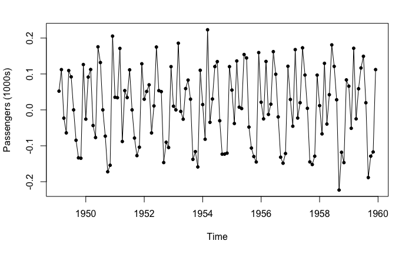

```r
plot(diff(log(AP_train)), ylab="Passengers (1000s)", type="o", pch =20)
```

# Ajustamos un modelo

Modelo lineal sobre la tendencia

```r
t <- seq(1, 144-12, 1)
t
```

```
  [1]   1   2   3   4   5   6   7   8   9  10  11  12  13  14  15  16  17  18  19  20  21  22  23  24  25  26  27
 [28]  28  29  30  31  32  33  34  35  36  37  38  39  40  41  42  43  44  45  46  47  48  49  50  51  52  53  54
 [55]  55  56  57  58  59  60  61  62  63  64  65  66  67  68  69  70  71  72  73  74  75  76  77  78  79  80  81
 [82]  82  83  84  85  86  87  88  89  90  91  92  93  94  95  96  97  98  99 100 101 102 103 104 105 106 107 108
[109] 109 110 111 112 113 114 115 116 117 118 119 120 121 122 123 124 125 126 127 128 129 130 131 132
```

```r
AP.decompM$trend
```

```
          Jan      Feb      Mar      Apr      May      Jun      Jul      Aug      Sep      Oct      Nov      Dec
1949       NA       NA       NA       NA       NA       NA 126.7917 127.2500 127.9583 128.5833 129.0000 129.7500
1950 131.2500 133.0833 134.9167 136.4167 137.4167 138.7500 140.9167 143.1667 145.7083 148.4167 151.5417 154.7083
1951 157.1250 159.5417 161.8333 164.1250 166.6667 169.0833 171.2500 173.5833 175.4583 176.8333 178.0417 180.1667
1952 183.1250 186.2083 189.0417 191.2917 193.5833 195.8333 198.0417 199.7500 202.2083 206.2500 210.4167 213.3750
1953 215.8333 218.5000 220.9167 222.9167 224.0833 224.7083 225.3333 225.3333 224.9583 224.5833 224.4583 225.5417
1954 228.0000 230.4583 232.2500 233.9167 235.6250 237.7500 240.5000 243.9583 247.1667 250.2500 253.5000 257.1250
1955 261.8333 266.6667 271.1250 275.2083 278.5000 281.9583 285.7500 289.3333 293.2500 297.1667 301.0000 305.4583
1956 309.9583 314.4167 318.6250 321.7500 324.5000 327.0833 329.5417 331.8333 334.4583 337.5417 340.5417 344.0833
1957 348.2500 353.0000 357.6250 361.3750 364.5000 367.1667 369.4583 371.2083 372.1667 372.4167 372.7500 373.6250
1958 375.2500 377.9167 379.5000 380.0000 380.7083 380.9583 381.8333 383.6667 386.5000 390.3333 394.7083 398.6250
1959 402.5417 407.1667 411.8750 416.3333 420.5000 425.5000       NA       NA       NA       NA       NA       NA
```

```r
modelTrend <- lm(formula = AP.decompM$trend ~ t)
summary(modelTrend)
```

```
Call:
lm(formula = AP.decompM$trend ~ t)

Residuals:
    Min      1Q  Median      3Q     Max
-21.419  -3.567   1.444   5.886  19.880

Coefficients:
            Estimate Std. Error t value Pr(>|t|)
(Intercept) 88.84686    1.91114   46.49   <2e-16 ***
t            2.58064    0.02549  101.25   <2e-16 ***
---
Signif. codes:  0 ‘***’ 0.001 ‘**’ 0.01 ‘*’ 0.05 ‘.’ 0.1 ‘ ’ 1

Residual standard error: 9.672 on 118 degrees of freedom
  (12 observations deleted due to missingness)
Multiple R-squared:  0.9886,    Adjusted R-squared:  0.9885
F-statistic: 1.025e+04 on 1 and 118 DF,  p-value: < 2.2e-16
```

Vamos a hacer una predicción con los datos de trainning

```r
predT <- predict.lm(modelTrend, newdata = data.frame(t))
```

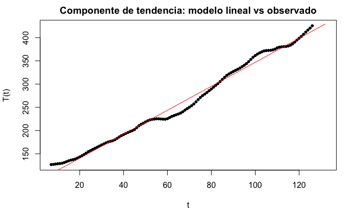

```r
plot(AP.decompM$trend[7:132] ~ t[7:132], ylab="T(t)", xlab="t",
     type="p", pch=20, main = "Componente de tendencia: modelo lineal vs observado")
lines(predT, col="red")
```

T(t)=2.58064t+88.84686

```r
Data1960 <- data.frame("T" = 2.58064*seq(123, 134, 1) + 88.84686, S=rep(0,12), e=rep(0,12),
                       row.names = c("Jan", "Feb", "Mar", "Apr", "May", "Jun", "Jul", "Aug", "Sep", "Oct", "Nov", "Dec"))
Data1960
```

|  | T | S | e |
| --- | --- | --- | --- |
| Jan | 406.2656 | 0 | 0 |
| Feb | 408.8462 | 0 | 0 |
| Mar | 411.4269 | 0 | 0 |
| Apr | 414.0075 | 0 | 0 |
| May | 416.5881 | 0 | 0 |
| Jun | 419.1688 | 0 | 0 |
| Jul | 421.7494 | 0 | 0 |
| Aug | 424.3301 | 0 | 0 |
| Sep | 426.9107 | 0 | 0 |
| Oct | 429.4913 | 0 | 0 |

[output cut: 2 more lines]

Modelo sobre la componente estacional

```r
Data1960$S <- unique(AP.decompM$seasonal)
Data1960
```

|  | T | S | e |
| --- | --- | --- | --- |
| Jan | 406.2656 | 0.9100037 | 0 |
| Feb | 408.8462 | 0.8873765 | 0 |
| Mar | 411.4269 | 1.0182037 | 0 |
| Apr | 414.0075 | 0.9754120 | 0 |
| May | 416.5881 | 0.9798128 | 0 |
| Jun | 419.1688 | 1.1115898 | 0 |
| Jul | 421.7494 | 1.2221466 | 0 |
| Aug | 424.3301 | 1.2135961 | 0 |
| Sep | 426.9107 | 1.0609168 | 0 |
| Oct | 429.4913 | 0.9217670 | 0 |

[output cut: 2 more lines]

# Predicciones y error

Las predicciones para ese año 1960 se realizan como

Y(t)=T(t)⋅S(t)

Observamos el valor del error hasta 1960 y debería distribuirse entorno a 1 con formato de campana de Gauss (Normal(1, ϵ))

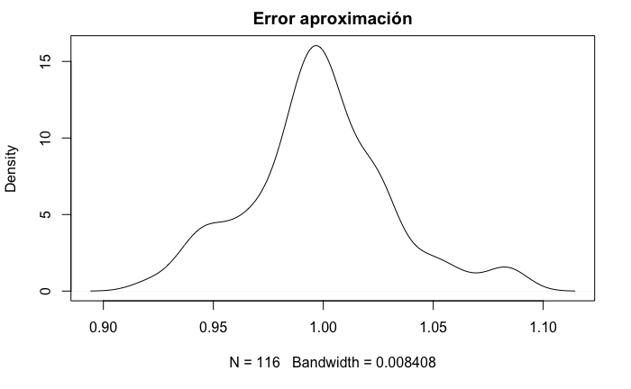

```r
plot(density(AP.decompM$random[7:122]),
             main="Error aproximación")
```

```r
sd_error <- sd(AP.decompM$random[7:122])
sd_error
```

```
[1] 0.03287385
```

```r
Data1960$e <- 1.10
Data1960
```

[output not shown]

[output cut: 2 more lines]

Modelo multiplicativo: Y(t)=T(t)⋅S(t)⋅ϵ(t)

```r
#Centro estimación
Data1960$R <- Data1960$T * Data1960$S * Data1960$e
#Extremo sup. 95% confianza
Data1960$O <- Data1960$T * Data1960$S * (Data1960$e+1.95*sd_error)
#Extremo inf. 95% confianza
Data1960$P <- Data1960$T * Data1960$S * (Data1960$e-1.95*sd_error)
Data1960$Real <- AP_test
Data1960
```

|  | T | S | e | R | O | P | Real |
| --- | --- | --- | --- | --- | --- | --- | --- |
| Jan | 406.2656 | 0.9100037 | 1.1 | 406.6735 | 430.3730 | 382.9740 | 417 |
| Feb | 408.8462 | 0.8873765 | 1.1 | 399.0806 | 422.3375 | 375.8236 | 391 |
| Mar | 411.4269 | 1.0182037 | 1.1 | 460.8080 | 487.6622 | 433.9538 | 419 |
| Apr | 414.0075 | 0.9754120 | 1.1 | 444.2107 | 470.0976 | 418.3237 | 461 |
| May | 416.5881 | 0.9798128 | 1.1 | 448.9962 | 475.1621 | 422.8304 | 472 |
| Jun | 419.1688 | 1.1115898 | 1.1 | 512.5381 | 542.4070 | 482.6693 | 535 |
| Jul | 421.7494 | 1.2221466 | 1.1 | 566.9836 | 600.0253 | 533.9418 | 622 |
| Aug | 424.3301 | 1.2135961 | 1.1 | 566.4618 | 599.4732 | 533.4505 | 606 |
| Sep | 426.9107 | 1.0609168 | 1.1 | 498.2084 | 527.2422 | 469.1746 | 508 |
| Oct | 429.4913 | 0.9217670 | 1.1 | 435.4801 | 460.8582 | 410.1019 | 461 |

[output cut: 2 more lines]

Representamos el valor de predicción y el real de 1960

```r
xr = c(123,134)
plot(Data1960$Real, xlim=xr, ylab = "Passengers (100s)", xlab = "Month" , lwd=10)
lines(Data1960$Real, x=seq(123,134,1), lwd=5)
```

```r
lines(Data1960$R, x=seq(123,134,1), col="blue")
lines(Data1960$O, x=seq(123,134,1), col="green")
```

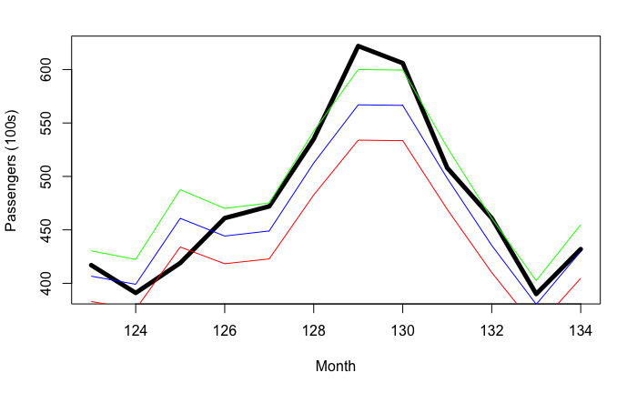

```r
lines(Data1960$P, x=seq(123,134,1), col="red")
```

El MAPE: Compute the mean absolute percentage error regression loss

```r
#install.packages("TSPred")
library(TSPred)
```

```r
MAPE(Data1960$Real, Data1960$R)
```

```
[1] 4.421319
```

```r
error <- Data1960$Real / Data1960$R
error
```

[output not shown]

```r
sd(error)
```

```
[1] 0.04673377
```

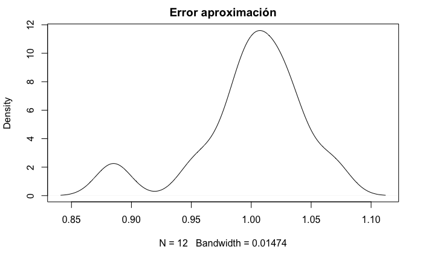

```r
plot(density(error),
             main="Error aproximación")
```

Podemos jugar con el Error -> linea 296